# Практикум по ANOVA и post hoc сравнениям

Цепелева И.

2022-11-24

```r
library(dplyr)

soccer_general <- read.csv("soccer.csv", sep=";")[, 2:6] %>%
    mutate(Position = as.factor(Position),
    Nationality = as.factor(Nationality),
    Age = as.numeric(Age),
    Height = as.numeric(Height)
) %>%
filter(Nationality %in% c("Spanish", "Italian", "German", "English", "Argentinian"))

set.seed(1)

soccer_wrk <- soccer_general[sample(1:nrow(soccer_general), 150), ] %>%
    mutate(Nationality = factor(Nationality))
```

ЗАДАНИЕ 1

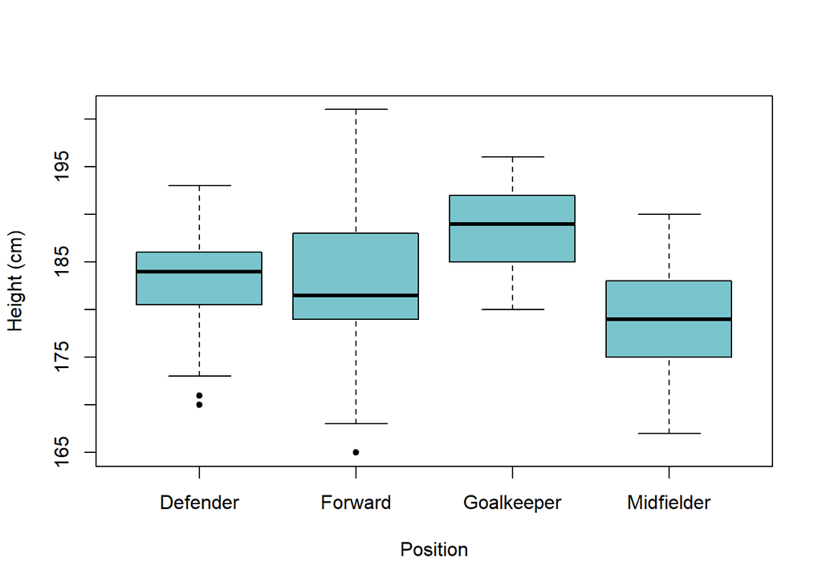

```r
soccer_wrk %>%
  with(
    boxplot(Height ~ Position, col = "cadetblue3", pch = 20,
            ylab = "Height (cm)")
  )
```

```r
aov(Height ~ Position, data = soccer_wrk) %>% summary
```

```
##              Df Sum Sq Mean Sq F value   Pr(>F)
## Position      3   1345   448.3   12.88 1.64e-07 ***
## Residuals   146   5082    34.8
## ---
## Signif. codes:  0 '***' 0.001 '**' 0.01 '*' 0.05 '.' 0.1 ' ' 1
```

```r
oneway.test(Height ~ Position, data = soccer_wrk) #Welch
```

```
##
##  One-way analysis of means (not assuming equal variances)
##
## data:  Height and Position
## F = 15.44, num df = 3.00, denom df = 62.23, p-value = 1.288e-07
```

И в том, и в другом случае p-value << 0.05 (1.64e-07 и 1.288e-07), значит, мы можем отвергнуть нулевую гипотезу об отсутствии взаимосвязи между ростом футболиста и его позицией на поле. Другими словами, позиция на поле ассоциирована со средним ростом футболиста, и существует как минимум одна пара групп со статистически значимо отличающимися значениями роста

ЗАДАНИЕ 2  
Процедура Хоторна-Брейца_Вестфала.

```r
library(multcomp)

m0 <- lm(Height ~ Position, data = soccer_wrk)
HBW.comp <- m0 %>%  glht(linfct = mcp(Position = "Tukey"))

HBW.comp %>% summary()
```

```
##
##   Simultaneous Tests for General Linear Hypotheses
##
## Multiple Comparisons of Means: Tukey Contrasts
##
##
## Fit: lm(formula = Height ~ Position, data = soccer_wrk)
##
## Linear Hypotheses:
##                              Estimate Std. Error t value Pr(>|t|)
## Forward - Defender == 0        -1.718      1.339  -1.283  0.57138
## Goalkeeper - Defender == 0      5.258      1.513   3.474  0.00366 **
## Midfielder - Defender == 0     -4.218      1.193  -3.535  0.00297 **
## Goalkeeper - Forward == 0       6.976      1.679   4.156  < 0.001 ***
## Midfielder - Forward == 0      -2.500      1.397  -1.790  0.27918
## Midfielder - Goalkeeper == 0   -9.476      1.565  -6.056  < 0.001 ***
## ---
## Signif. codes:  0 '***' 0.001 '**' 0.01 '*' 0.05 '.' 0.1 ' ' 1
## (Adjusted p values reported -- single-step method)
```

```r
HBW.comp %>% confint()
```

```
##
##   Simultaneous Confidence Intervals
##
## Multiple Comparisons of Means: Tukey Contrasts
##
##
## Fit: lm(formula = Height ~ Position, data = soccer_wrk)
##
## Quantile = 2.5918
## 95% family-wise confidence level
##
##
## Linear Hypotheses:
##                              Estimate lwr      upr
## Forward - Defender == 0       -1.7182  -5.1889   1.7525
## Goalkeeper - Defender == 0     5.2580   1.3355   9.1806
## Midfielder - Defender == 0    -4.2182  -7.3111  -1.1253
## Goalkeeper - Forward == 0      6.9762   2.6254  11.3270
## Midfielder - Forward == 0     -2.5000  -6.1206   1.1206
## Midfielder - Goalkeeper == 0  -9.4762 -13.5320  -5.4204
```

Cтатистически значимые различия (p-value < 0.05) выявлены между группами :  
Goalkeeper - Defender  
Midfielder - Defender  
Goalkeeper - Forward  
Midfielder - Goalkeeper

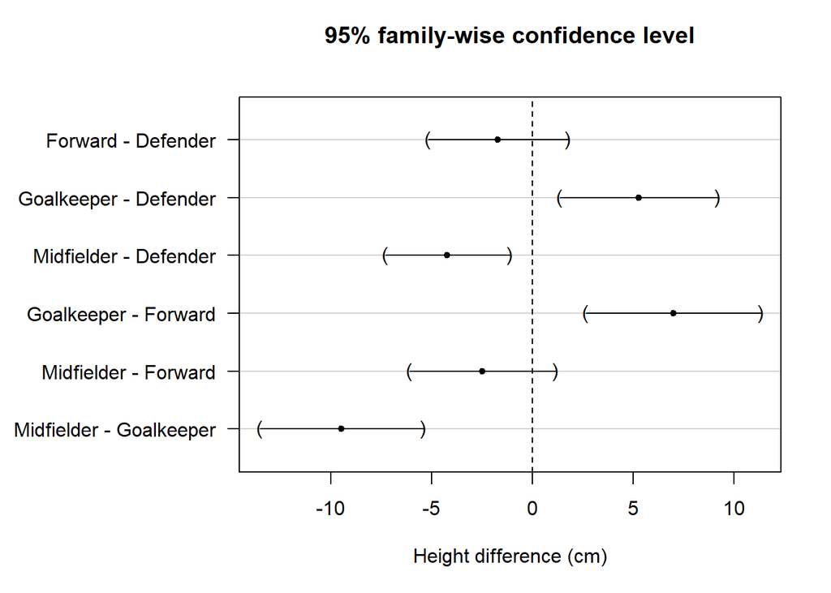

```r
library(ggplot2)
par(mar = c(5, 10, 4, 2)+0.1)
HBW.comp %>% plot(xlab = "Height difference (cm)")
```

ЗАДАНИЕ 3  
Сравните результаты с результатами, которые вы получили в предыдущем домашнем задании.

Процедура Хоторна-Бретца-Вестфалла еще раз подтвердила статистически значимые различия между группами, полученные в предыдущем домашнем задании.

ЗАДАНИЕ 4  
Используйте дисперсионный анализ и постхок процедуру ХБФ для того, чтобы выяснить и описать наличие связи между ростом футболиста и страной, за которую он играет. Опишите и интерпретируйте полученные результаты.

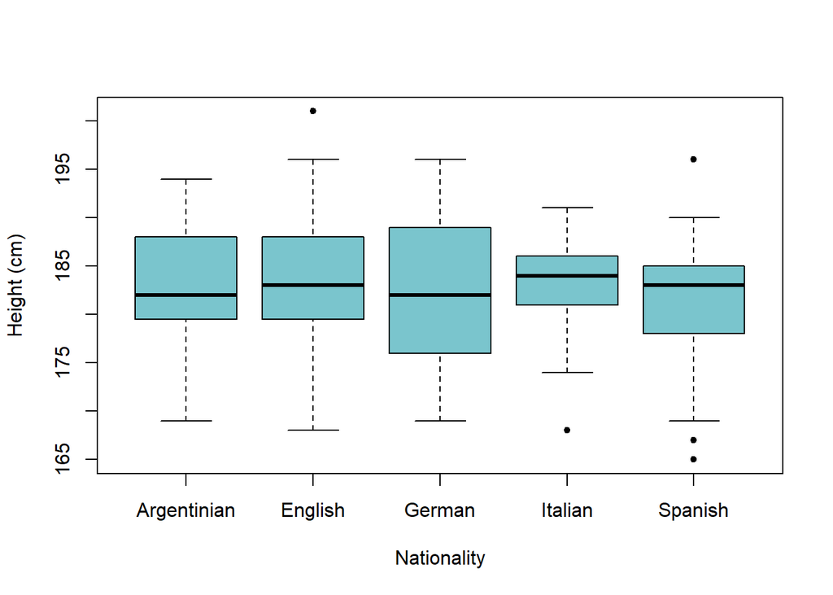

```r
soccer_wrk %>%
  with(
    boxplot(Height ~ Nationality, col = "cadetblue3", pch = 20,
            ylab = "Height (cm)")
  )
```

На первый вгляд значимых различий в росте футболистов в зависимости от их национальности не наблюдается, применим дисперсионный анализ:

```r
aov(Height ~ Nationality, data = soccer_wrk) %>% summary
```

```
##              Df Sum Sq Mean Sq F value Pr(>F)
## Nationality   4    164   41.03    0.95  0.437
## Residuals   145   6263   43.19
```

```r
oneway.test(Height ~ Nationality, data = soccer_wrk)
```

```
##
##  One-way analysis of means (not assuming equal variances)
##
## data:  Height and Nationality
## F = 0.95703, num df = 4.000, denom df = 55.927, p-value = 0.4383
```

p-value > 0.05 в обоих случаях, нулевую гипотезу о об отсутствии взаимосвязи между ростом футболиста и его национальностью отвергнуть НЕ можем.  
Постхок процедура ХБФ:

```r
library(multcomp)

m0 <- lm(Height ~ Nationality, data = soccer_wrk)
HBW.comp <- m0 %>%  glht(linfct = mcp(Nationality = "Tukey"))

HBW.comp %>% summary()
```

```
##
##   Simultaneous Tests for General Linear Hypotheses
##
## Multiple Comparisons of Means: Tukey Contrasts
##
##
## Fit: lm(formula = Height ~ Nationality, data = soccer_wrk)
##
## Linear Hypotheses:
##                            Estimate Std. Error t value Pr(>|t|)
## English - Argentinian == 0  0.71111    2.11643   0.336    0.997
## German - Argentinian == 0  -1.14667    2.14645  -0.534    0.983
## Italian - Argentinian == 0  0.08485    2.04656   0.041    1.000
## Spanish - Argentinian == 0 -1.94667    1.93478  -1.006    0.849
## German - English == 0      -1.85778    1.82413  -1.018    0.844
## Italian - English == 0     -0.62626    1.70546  -0.367    0.996
## Spanish - English == 0     -2.65778    1.56958  -1.693    0.436
## Italian - German == 0       1.23152    1.74258   0.707    0.954
## Spanish - German == 0      -0.80000    1.60984  -0.497    0.987
## Spanish - Italian == 0     -2.03152    1.47402  -1.378    0.638
## (Adjusted p values reported -- single-step method)
```

```r
HBW.comp %>% confint()
```

```
##
##   Simultaneous Confidence Intervals
##
## Multiple Comparisons of Means: Tukey Contrasts
##
##
## Fit: lm(formula = Height ~ Nationality, data = soccer_wrk)
##
## Quantile = 2.7526
## 95% family-wise confidence level
##
##
## Linear Hypotheses:
##                            Estimate lwr      upr
## English - Argentinian == 0  0.71111 -5.11466  6.53688
## German - Argentinian == 0  -1.14667 -7.05508  4.76174
## Italian - Argentinian == 0  0.08485 -5.54860  5.71830
## Spanish - Argentinian == 0 -1.94667 -7.27244  3.37910
## German - English == 0      -1.85778 -6.87896  3.16341
## Italian - English == 0     -0.62626 -5.32080  4.06828
## Spanish - English == 0     -2.65778 -6.97829  1.66273
## Italian - German == 0       1.23152 -3.56519  6.02822
## Spanish - German == 0      -0.80000 -5.23131  3.63131
## Spanish - Italian == 0     -2.03152 -6.08897  2.02594
```

p-value > 0.05 также во всех случаях, значит, статистически значимых различий между ростом спортсмена в зависимости от национальности не выявлено.